# Reproducible Pitch Presentation

12/17/2019

## Intro

This presentation is the third and final project of the “Developing Data Products” course in the Data Science Specialization provided by Johns Hopkins University on Coursera.

We were instructed to create a Shiny Application and publish it to a shiny server.

My app is available [here.](https://dandewaters.shinyapps.io/predictUSpop/)

The source code and instructions for running the app is available [here.](https://github.com/dandewaters/Developing-Data-Products-Course-Projects)

## US Population Data Set

I built my app from the “uspop” data set provided by the datasets package in R. It is a time series of the US population size in millions from 1790 to 1970. It was obtained from census data.

```
## [1]  3.93  5.31  7.24  9.64 12.90 17.10
```

## Scatterplot of Data Set

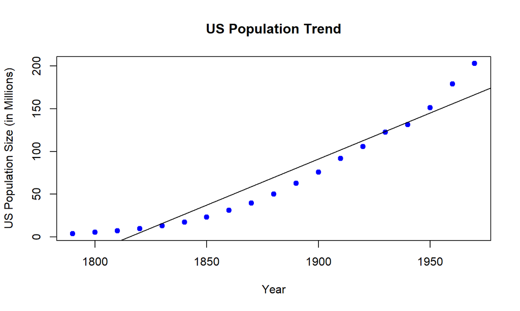

## My App

My app fits a linear model from this dataset and predicts the US population in a year that is input by the user. It displays a scatterplot of the data set and a trendline of the predictions of the linear model fit by the data set, similar to the scatterplot shown in th eprevious slide. Once the user picks a year to predict from, the scatterplot is reconstructed to fit the input year and population prediction point and the population prediction is displayed for the user.

## How to Use

1. Enter a year between 1790 and 3000 in the numeric input box in the left side panel
2. The predicted US population size (in millions) will be displayed in the main panel under the scatterplot. The year and population prediction point will also be added to the scatter plot in the main panel as well.

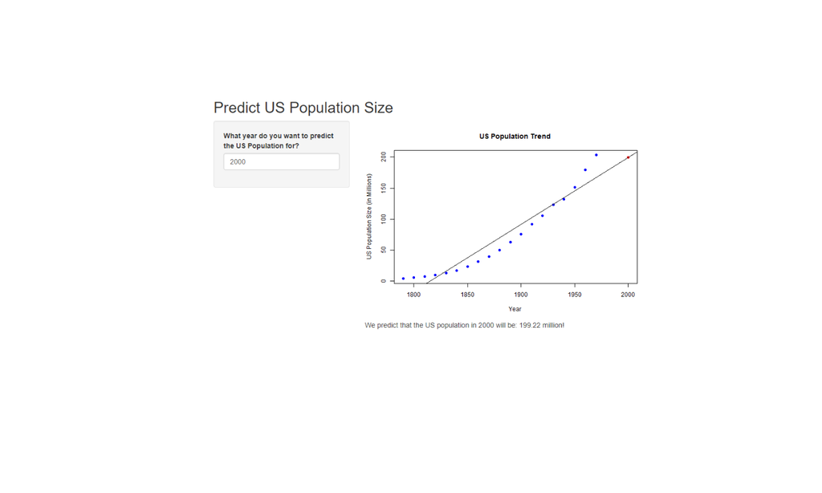

## Thank You

Thank you for checking out my app!